# EasyVisa Project

### Gradient Boosting Classifier

```python
gbc = GradientBoostingClassifier(random_state=1)
gbc.fit(X_train,y_train)
```

```
GradientBoostingClassifier(random_state=1)
```

```python
#Using above defined function to get accuracy, recall, precision and F1_score on train and test set
gbc_score=get_metrics_score(gbc)
```

```
Accuracy on training set :  0.7572423085560297
Accuracy on test set :  0.7476096922069417
Recall on training set :  0.8805042016806722
Recall on test set :  0.8678690452852382
Precision on training set :  0.7831091180866966
Precision on test set :  0.7794014084507043
F1 score on training set :  0.8289556962025317
F1 score on test set :  0.8212596234115574
```

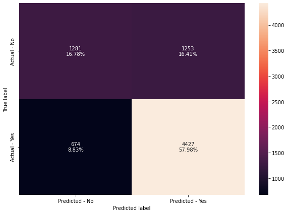

```python
make_confusion_matrix(gbc,y_test)
```

- The Gradient Boosting Classifier model is not overfitting.
- Results are very similiar compared to the AdaBoost model. Slightly higher score in terms of Accuracy, Precision and F1 score. But slightly lower score for Recall.
- Since F1 score our point of focus we can deduce that the Gradient Boosting Classifier model is a slight improvement.
- Let's try the default XGBoost Classifier model

```python
xgb = XGBClassifier(random_state=1,eval_metric='logloss')
xgb.fit(X_train,y_train)
```

```
XGBClassifier(base_score=0.5, booster='gbtree', callbacks=None,
              colsample_bylevel=1, colsample_bynode=1, colsample_bytree=1,
              early_stopping_rounds=None, enable_categorical=False,
              eval_metric='logloss', gamma=0, gpu_id=-1,
              grow_policy='depthwise', importance_type=None,
              interaction_constraints='', learning_rate=0.300000012,
              max_bin=256, max_cat_to_onehot=4, max_delta_step=0, max_depth=6,
              max_leaves=0, min_child_weight=1, missing=nan,
              monotone_constraints='()', n_estimators=100, n_jobs=0,
              num_parallel_tree=1, predictor='auto', random_state=1,
              reg_alpha=0, reg_lambda=1, ...)
```

### XGBoost Classifier

```python
#Using above defined function to get accuracy, recall, precision and F1_score on train and test set
xgb_score=get_metrics_score(xgb)
```

```
Accuracy on training set :  0.8329216258701999
Accuracy on test set :  0.7304518664047152
Recall on training set :  0.9281512605042017
Recall on test set :  0.8512056459517742
Precision on training set :  0.8389032356068662
Precision on test set :  0.7697216805530934
F1 score on training set :  0.8812734381233543
F1 score on test set :  0.8084155650716812
```

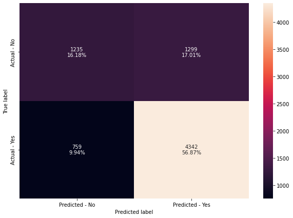

```python
make_confusion_matrix(xgb,y_test)
```

- The XGBoost Classifier model is overfitting and is therefore not a improvement on the Gradient Classifier model.

```python
# defining list of models
models = [bagging_estimator, rf_estimator, abc, gbc, xgb]

# defining empty lists to add train and test results
acc_train = []
acc_test = []
recall_train = []
recall_test = []
precision_train = []
precision_test = []
f1_score_train = []
f1_score_test = []

# looping through all the models to get the accuracy, precall and precision scores
for model in models:
    j = get_metrics_score(model,False)
    acc_train.append(np.round(j[0],2))
    acc_test.append(np.round(j[1],2))
    recall_train.append(np.round(j[2],2))
    recall_test.append(np.round(j[3],2))
    precision_train.append(np.round(j[4],2))
    precision_test.append(np.round(j[5],2))
    f1_score_train.append(np.round(j[6],2))
    f1_score_test.append(np.round(j[7],2))
```

```python
comparison_frame = pd.DataFrame({'Model':['Bagging classifier (default)', 'Random forest (default)',
                                        'AdaBoost (default)',
                                          'Gradient Boosting (default)',
                                          'XGBoost (default)'],
                                          'Train_Accuracy': acc_train,'Test_Accuracy': acc_test,
                                          'Train_Recall':recall_train,'Test_Recall':recall_test,
                                          'Train_Precision':precision_train,'Test_Precision':precision_test,
                                          'Train_F1_score':f1_score_train,'Test_F1_score':f1_score_test})
comparison_frame
```

|  | Model | Train_Accuracy | Test_Accuracy | Train_Recall | Test_Recall | Train_Precision | Test_Precision | Train_F1_score | Test_F1_score |
| --- | --- | --- | --- | --- | --- | --- | --- | --- | --- |
| 0 | Bagging classifier (default) | 0.98 | 0.70 | 0.99 | 0.78 | 0.99 | 0.77 | 0.99 | 0.78 |
| 1 | Random forest (default) | 1.00 | 0.72 | 1.00 | 0.83 | 1.00 | 0.77 | 1.00 | 0.80 |
| 2 | AdaBoost (default) | 0.74 | 0.73 | 0.89 | 0.88 | 0.76 | 0.76 | 0.82 | 0.82 |
| 3 | Gradient Boosting (default) | 0.76 | 0.75 | 0.88 | 0.87 | 0.78 | 0.78 | 0.83 | 0.82 |
| 4 | XGBoost (default) | 0.83 | 0.73 | 0.93 | 0.85 | 0.84 | 0.77 | 0.88 | 0.81 |

- The best preforming model currently is Gradient Boosting. Followed by AdaBoost. The others overfitted the data. Now let's try to improve these models using hyperparameters.

## Will tuning the hyperparameters improve the model performance?

### Bagging Classifier tuned

```python
# Choose the type of classifier.
bagging_estimator_tuned = BaggingClassifier(random_state=1)

# Grid of parameters to choose from
## add from article
parameters = {'max_samples': [0.7,0.8,0.9,1],
              'max_features': [0.7,0.8,0.9,1],
              'n_estimators' : [10,20,30,40,50],
             }

# Type of scoring used to compare parameter combinations
acc_scorer = metrics.make_scorer(metrics.recall_score)

# Run the grid search
grid_obj = GridSearchCV(bagging_estimator_tuned, parameters, scoring=acc_scorer,cv=5)
grid_obj = grid_obj.fit(X_train, y_train)

# Set the clf to the best combination of parameters
bagging_estimator_tuned = grid_obj.best_estimator_

# Fit the best algorithm to the data.
bagging_estimator_tuned.fit(X_train, y_train)
```

```
BaggingClassifier(max_features=0.7, max_samples=1, n_estimators=30,
                  random_state=1)
```

```python
#Using above defined function to get accuracy, recall, precision and F1_score on train and test set
bagging_estimator_tuned_score=get_metrics_score(bagging_estimator_tuned)
```

```
Accuracy on training set :  0.6680889288120369
Accuracy on test set :  0.6681074001309758
Recall on training set :  1.0
Recall on test set :  1.0
Precision on training set :  0.6680889288120369
Precision on test set :  0.6681074001309758
F1 score on training set :  0.8010231556273559
F1 score on test set :  0.801036432160804
```

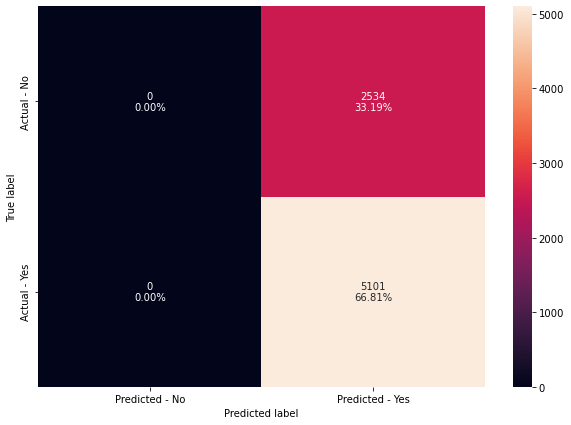

```python
make_confusion_matrix(bagging_estimator_tuned,y_test)
```

- The tuned Bagging Classifier model is not overfitting. Therefore this model is better than the default Bagging Classifier model.
- However this model did not perform as well as the Gradient Boosting model. For 2 reasons. Firstly, for the Gradient Boosting model, the scores of accuracy, recall, precision and F1_score are similiar. However, with this model there is a large discrepency between recall and the other scores. Secondly, this model has low scores for Accuracy and Precision, and a lower F1 score compared to the Gradient Boosting model.
- Let's try the tuned Random Forest Classifier

### Random Forest Classifier tuned

```python
# Choose the type of classifier.
rf_estimator_tuned = RandomForestClassifier(random_state=1)

# Grid of parameters to choose from
## add from article
parameters = {"n_estimators": [50,100,150],
    "min_samples_leaf": np.arange(3, 7),
    "max_features": np.arange(0.2, 0.7, 0.1),
    "max_samples": np.arange(0.3, 0.7, 0.1),
             }

# Type of scoring used to compare parameter combinations
acc_scorer = metrics.make_scorer(metrics.recall_score)

# Run the grid search
grid_obj = GridSearchCV(rf_estimator_tuned, parameters, scoring=acc_scorer,cv=5)
grid_obj = grid_obj.fit(X_train, y_train)

# Set the clf to the best combination of parameters
rf_estimator_tuned = grid_obj.best_estimator_

# Fit the best algorithm to the data.
rf_estimator_tuned.fit(X_train, y_train)
```

```
RandomForestClassifier(max_features=0.2, max_samples=0.3, min_samples_leaf=5,
                       random_state=1)
```

```python
#Using above defined function to get accuracy, recall, precision and F1_score on train and test set
rf_estimator_tuned_score=get_metrics_score(rf_estimator_tuned)
```

```
Accuracy on training set :  0.7688636874017516
Accuracy on test set :  0.7469548133595285
Recall on training set :  0.894453781512605
Recall on test set :  0.8749264850029406
Precision on training set :  0.7881525360977416
Precision on test set :  0.7752301545944068
F1 score on training set :  0.8379452863609526
F1 score on test set :  0.822066678946399
```

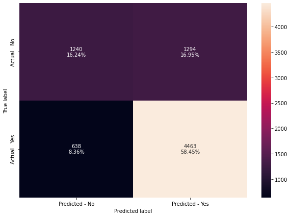

```python
make_confusion_matrix(rf_estimator_tuned,y_test)
```

### Random Forest Classifier class_weights

```python
# Choose the type of classifier.
rf_estimator_weighted = RandomForestClassifier(random_state=1)

# Grid of parameters to choose from
## add from article
parameters = {
    "class_weight": [{0: 0.3, 1: 0.7}],
    "n_estimators": [20,50,100,150],
    "min_samples_leaf": np.arange(3, 7),
    "max_features": np.arange(0.2, 0.7, 0.1),
    "max_samples": np.arange(0.3, 0.7, 0.1),
}

# Type of scoring used to compare parameter combinations
acc_scorer = metrics.make_scorer(metrics.recall_score)

# Run the grid search
grid_obj = GridSearchCV(rf_estimator_weighted, parameters, scoring=acc_scorer,cv=5)
grid_obj = grid_obj.fit(X_train, y_train)

# Set the clf to the best combination of parameters
rf_estimator_weighted = grid_obj.best_estimator_

# Fit the best algorithm to the data.
rf_estimator_weighted.fit(X_train, y_train)
```

```
RandomForestClassifier(class_weight={0: 0.3, 1: 0.7}, max_features=0.2,
                       max_samples=0.3, min_samples_leaf=6, n_estimators=150,
                       random_state=1)
```

```python
#Using above defined function to get accuracy, recall, precision and F1_score on train and test set
rf_estimator_weighted_score=get_metrics_score(rf_estimator_weighted)
```

```
Accuracy on training set :  0.7331012800359308
Accuracy on test set :  0.7098886705959397
Recall on training set :  0.9796638655462185
Recall on test set :  0.9621642815134287
Precision on training set :  0.7209647495361781
Precision on test set :  0.7082251082251082
F1 score on training set :  0.8306376914855718
F1 score on test set :  0.8158922782811071
```

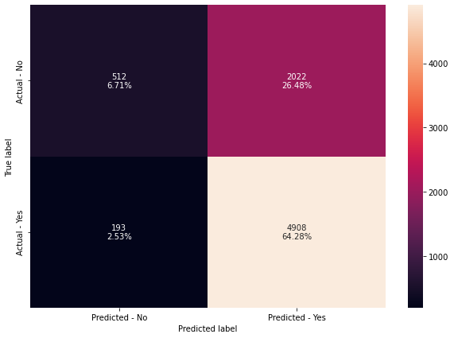

```python
make_confusion_matrix(rf_estimator_weighted,y_test)
```

- The tuned Random Forest Classifier model with class_weights is not overfitting.
- The model has a better recall score compared to the tuned Random Forest Classifier model.
- However, the model has a lower score for accuracy, precision, and F1 score. Therefore this model is not has high performing as the tuned Random Forest Classifer model.
- Let's try tuned AdaBoost Classifier

### Tuned AdaBoost Classifier

```python
# Choose the type of classifier.
abc_tuned = AdaBoostClassifier(random_state=1)

# Grid of parameters to choose from
## add from article
parameters = {
    #Let's try different max_depth for base_estimator
    "base_estimator":[DecisionTreeClassifier(max_depth=1, random_state=1),DecisionTreeClassifier(max_depth=2, random_state=1),DecisionTreeClassifier(max_depth=3, random_state=1)],
    "n_estimators": np.arange(10,110,10),
    "learning_rate":np.arange(0.1,2,0.1)
}

# Type of scoring used to compare parameter combinations
acc_scorer = metrics.make_scorer(metrics.recall_score)

# Run the grid search
grid_obj = GridSearchCV(abc_tuned, parameters, scoring=acc_scorer,cv=5)
grid_obj = grid_obj.fit(X_train, y_train)

# Set the clf to the best combination of parameters
abc_tuned = grid_obj.best_estimator_

# Fit the best algorithm to the data.
abc_tuned.fit(X_train, y_train)
```

```
AdaBoostClassifier(base_estimator=DecisionTreeClassifier(max_depth=1,
                                                         random_state=1),
                   learning_rate=0.1, n_estimators=20, random_state=1)
```

```python
#Using above defined function to get accuracy, recall, precision and F1_score on train and test set
abc_tuned_score=get_metrics_score(abc_tuned)
```

```
Accuracy on training set :  0.6916123961374354
Accuracy on test set :  0.6910281597904387
Recall on training set :  0.9715966386554622
Recall on test set :  0.9684375612624976
Precision on training set :  0.6916312735538673
Precision on test set :  0.6920706080134491
F1 score on training set :  0.8080511584023483
F1 score on test set :  0.8072554947299616
```

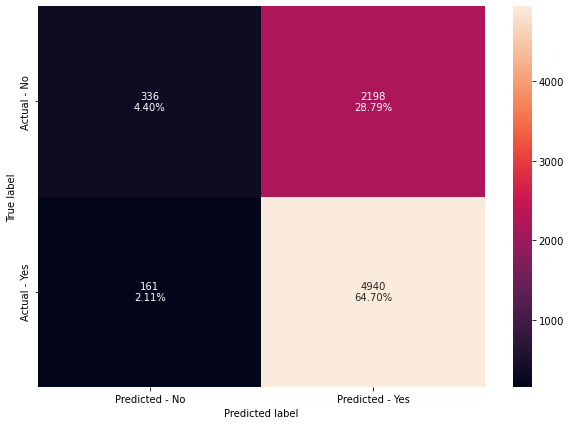

```python
make_confusion_matrix(abc_tuned,y_test)
```

- The tuned AdaBoost Classifier model is not overfitting.
- However the model is not performing as well as the default AdaBoost Classifier model nor the tuned Random Forest Classifier model.
- Let's try the tuned Gradient Boosting Classifier

### Tuned Gradient Boosting Classifier

```python
# Choose the type of classifier.
gbc_tuned = GradientBoostingClassifier(init=AdaBoostClassifier(random_state=1),random_state=1)

# Grid of parameters to choose from
## add from article
parameters = {
    "n_estimators": [20,50,100,150],
    "subsample":[0.8,0.9,1],
    "max_features":[0.7,0.8,0.9,1]
}

# Type of scoring used to compare parameter combinations
acc_scorer = metrics.make_scorer(metrics.recall_score)

# Run the grid search
grid_obj = GridSearchCV(gbc_tuned, parameters, scoring=acc_scorer,cv=5)
grid_obj = grid_obj.fit(X_train, y_train)

# Set the clf to the best combination of parameters
gbc_tuned = grid_obj.best_estimator_

# Fit the best algorithm to the data.
gbc_tuned.fit(X_train, y_train)
```

```
GradientBoostingClassifier(init=AdaBoostClassifier(random_state=1),
                           max_features=1, n_estimators=20, random_state=1,
                           subsample=1)
```

```python
#Using above defined function to get accuracy, recall, precision and F1_score on train and test set
gbc_tuned_score=get_metrics_score(gbc_tuned)
```

```
Accuracy on training set :  0.685773635751179
Accuracy on test set :  0.6848722986247544
Recall on training set :  0.9878991596638655
Recall on test set :  0.9874534405018623
Precision on training set :  0.6831309198675112
Precision on test set :  0.6826128201653341
F1 score on training set :  0.8077226974475249
F1 score on test set :  0.8072115384615384
```

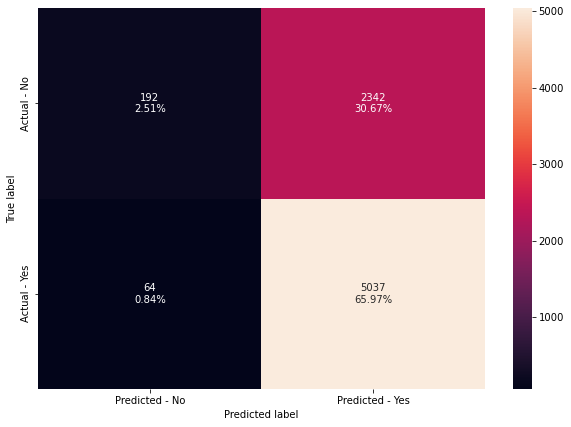

```python
make_confusion_matrix(gbc_tuned,y_test)
```

- The tuned Gradient Boost Classifier model is not overfitting.
- However the model is not performing as well as the default Gradient Boost Classifier model nor the tuned Random Forest Classifier model.
- Let's try the tuned XGBClassifier model

### Tuned XGBClassifier model

```python
# Choose the type of classifier.
xgb_tuned = XGBClassifier(random_state=1,eval_metric='logloss')

# Grid of parameters to choose from
## add from
parameters = {
    "n_estimators": np.arange(10,30,50),
    "scale_pos_weight":[1,2,5],
    "subsample":[0.7,0.9,1.0],
    "learning_rate":[0.05,0.1,0.2],
    "colsample_bytree":[0.5,0.6,0.7],
    "colsample_bylevel":[0.5,0.6,0.7]
}

# Type of scoring used to compare parameter combinations
acc_scorer = metrics.make_scorer(metrics.recall_score)

# Run the grid search
grid_obj = GridSearchCV(xgb_tuned, parameters,scoring=acc_scorer,cv=5)
grid_obj = grid_obj.fit(X_train, y_train)

# Set the clf to the best combination of parameters
xgb_tuned = grid_obj.best_estimator_

# Fit the best algorithm to the data.
xgb_tuned.fit(X_train, y_train)
```

```
XGBClassifier(base_score=0.5, booster='gbtree', callbacks=None,
              colsample_bylevel=0.5, colsample_bynode=1, colsample_bytree=0.5,
              early_stopping_rounds=None, enable_categorical=False,
              eval_metric='logloss', gamma=0, gpu_id=-1,
              grow_policy='depthwise', importance_type=None,
              interaction_constraints='', learning_rate=0.05, max_bin=256,
              max_cat_to_onehot=4, max_delta_step=0, max_depth=6, max_leaves=0,
              min_child_weight=1, missing=nan, monotone_constraints='()',
              n_estimators=10, n_jobs=0, num_parallel_tree=1, predictor='auto',
              random_state=1, reg_alpha=0, reg_lambda=1, ...)
```

```python
#Using above defined function to get accuracy, recall, precision and F1_score on train and test set
xgb_tuned_score=get_metrics_score(xgb_tuned)
```

```
Accuracy on training set :  0.6682012126656187
Accuracy on test set :  0.6681074001309758
Recall on training set :  1.0
Recall on test set :  1.0
Precision on training set :  0.6681639528354857
Precision on test set :  0.6681074001309758
F1 score on training set :  0.8010770784247728
F1 score on test set :  0.801036432160804
```

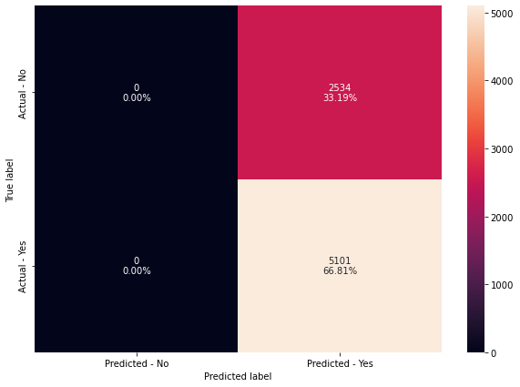

```python
make_confusion_matrix(xgb_tuned,y_test)
```

- The tuned XGBClassifier model is not overfitting.
- However the model is not performing as well as the tuned Random Forest Classifier model.

## Model Performance Comparison and Conclusions

```python
# defining list of models
models = [bagging_estimator, bagging_estimator_tuned, rf_estimator, rf_estimator_tuned, rf_estimator_weighted, abc, abc_tuned,
          gbc, gbc_tuned, xgb, xgb_tuned]

# defining empty lists to add train and test results
acc_train = []
acc_test = []
recall_train = []
recall_test = []
precision_train = []
precision_test = []
f1_score_train = []
f1_score_test = []

# looping through all the models to get the accuracy, precall and precision scores
for model in models:
    j = get_metrics_score(model,False)
    acc_train.append(np.round(j[0],2))
    acc_test.append(np.round(j[1],2))
    recall_train.append(np.round(j[2],2))
    recall_test.append(np.round(j[3],2))
    precision_train.append(np.round(j[4],2))
    precision_test.append(np.round(j[5],2))
    f1_score_train.append(np.round(j[6],2))
    f1_score_test.append(np.round(j[7],2))
```

```python
comparison_frame = pd.DataFrame({'Model':['Bagging classifier (default)', "Bagging classifier (tuned)",
                                          'Random forest (default)', "Random forest (tuned)", "Random forest (weighted)",
                                          'AdaBoost (default)', "AdaBoost (weighted)",
                                          'Gradient Boosting (default)', "Gradient Boosting (tuned)",
                                          'XGBoost (default)',"XGBoost (tuned)"],
                                          'Train_Accuracy': acc_train,'Test_Accuracy': acc_test,
                                          'Train_Recall':recall_train,'Test_Recall':recall_test,
                                          'Train_Precision':precision_train,'Test_Precision':precision_test,
                                          'Train_F1_score':f1_score_train,'Test_F1_score':f1_score_test})
comparison_frame
```

|  | Model | Train_Accuracy | Test_Accuracy | Train_Recall | Test_Recall | Train_Precision | Test_Precision | Train_F1_score | Test_F1_score |
| --- | --- | --- | --- | --- | --- | --- | --- | --- | --- |
| 0 | Bagging classifier (default) | 0.98 | 0.70 | 0.99 | 0.78 | 0.99 | 0.77 | 0.99 | 0.78 |
| 1 | Bagging classifier (tuned) | 0.67 | 0.67 | 1.00 | 1.00 | 0.67 | 0.67 | 0.80 | 0.80 |
| 2 | Random forest (default) | 1.00 | 0.72 | 1.00 | 0.83 | 1.00 | 0.77 | 1.00 | 0.80 |
| 3 | Random forest (tuned) | 0.77 | 0.75 | 0.89 | 0.87 | 0.79 | 0.78 | 0.84 | 0.82 |
| 4 | Random forest (weighted) | 0.73 | 0.71 | 0.98 | 0.96 | 0.72 | 0.71 | 0.83 | 0.82 |
| 5 | AdaBoost (default) | 0.74 | 0.73 | 0.89 | 0.88 | 0.76 | 0.76 | 0.82 | 0.82 |
| 6 | AdaBoost (weighted) | 0.69 | 0.69 | 0.97 | 0.97 | 0.69 | 0.69 | 0.81 | 0.81 |
| 7 | Gradient Boosting (default) | 0.76 | 0.75 | 0.88 | 0.87 | 0.78 | 0.78 | 0.83 | 0.82 |
| 8 | Gradient Boosting (tuned) | 0.69 | 0.68 | 0.99 | 0.99 | 0.68 | 0.68 | 0.81 | 0.81 |
| 9 | XGBoost (default) | 0.83 | 0.73 | 0.93 | 0.85 | 0.84 | 0.77 | 0.88 | 0.81 |
| 10 | XGBoost (tuned) | 0.67 | 0.67 | 1.00 | 1.00 | 0.67 | 0.67 | 0.80 | 0.80 |

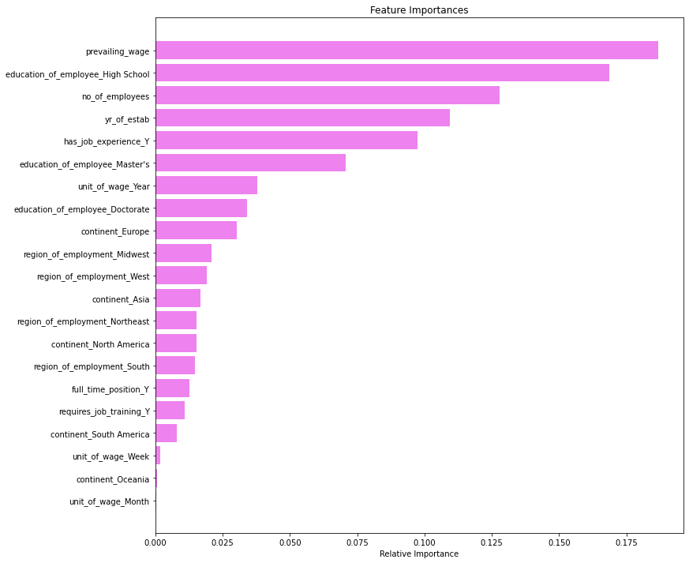

```python
#Check which features the tuned random forest model (the best fit model) considered the most important for prediction
importances = rf_estimator_tuned.feature_importances_
indices = np.argsort(importances)
feature_names = list(X.columns)

plt.figure(figsize=(12,12))
plt.title('Feature Importances')
plt.barh(range(len(indices)), importances[indices], color='violet', align='center')
plt.yticks(range(len(indices)), [feature_names[i] for i in indices])
plt.xlabel('Relative Importance')
plt.show()
```

### Comments on modelling

- We have been able to build a predictive model that can be used by INA to identify which applicants will be certified for a working visa with an f1_score of 0.84 on the training set and 0.82 on the test set.
- The f1_score for the tuned Random Forest Classifier model was higher than the other models. It is therefore advised to use this model.
- The model considered these 5 features to be the most important for predicition:
  - Prevailing wage
  - Education of employee (High school)
  - Number of employees
  - Year of establishment
  - Has job experience

## Actionable Insights and Recommendations

#### Observations from EDA:

- Most applications come from Asia (66.2%). Second most common is Europe (14.6%) and third is North America (12.9%).
- Most applications have bachelor's (40.2%). Second most common is a master's (37.8%), followed by a high school diploma (13.4%), followed by a doctorate (8.6%).
- 58.1% of applicants have job experience. The others have no previous experience.
- 88.4% of applicants do not require job training.
- Most applications are looking for work in the Northeast region (28.3%). Second most common is the South (27.5%), followed by the West (25.8%). Island region is the least common (1.5%).
- Median prevailing wage is around 65'000 USD. Prevailing wage ranges from 0 to 300'000.
- Most common unit of wage is year (90.1%). Second most common is hour (8.5%), followed by week (1.1%), followed by month (0.3%).
- Most applicants are applying for full time positions (89.4%).
- 66.8% of applicants are certified and approved for a working visa. 33.2% are denied.
- Chances of being accepted varies depending on the region. Applicants from South America have the lowest chance of being certified (about 60%), while applicants from Europe have the highest chance (about 80%).
- Chances of being accepted varies depending on a applicants level of education. Applicants with only a high school diploma have the lowest chance (about 35%). Applicants with a doctorate have the highest chance (about 90%).
- Applicants with previous job experience have a higher chance of being certified. (About 75% compared to about 60% for unexperienced applicants).
- Where applicants are applying affects there chances. Applicants who apply to the Midwest have about 75% chance of being certified. The highest of the regions.Applicants who apply to either the Island, the West, or the Northeast region have about 60% chance of being certified. The lowest of the regions.
- Applicants who apply for a position with a lower prevailing wage are less likely to be certified.
- Chances of being accepted varies depending on unit of wage. Applicants who apply for hourly salaries have the lowest chance of being certified (about 40%). Applicants who apply for yearly salaries have the highest chance (about 70%).
- Applicants with a master's are on average applying for the highest salary positions. Applicants with a doctorate are on average applying for the lowest salary positions.
- Applicants with job experience are less likely to need job training. About 10% need training. Applicants with no job experience are more likely to need job training. About 20% need training.
- Positions in Island have the highest prevailing wage, followed by the Midwest, followed by the South.

#### Recommendations

- Overall, the tuned Random Forest Classifier model performed better than the other models. The model's F1_score was 0.84 on the training set and 0.82 on the test set. It is therefore advised to use this model.
- Based on the model, the features that affect visa certification are the following:
  - Prevailing wage
  - Education of employee (High school)
  - Number of employees
  - Year of establishment
  - Has job experience
- Applicants who apply for a position with a lower prevailing wage are less likely to be certified. Applicants might be applying for a lower paying job for several reasons. For example they might have fewer educational qualificiations, and are less experienced. INA should consider giving these positions to US citizens since there are sufficient individuals locally based who can fufill these positions.
- Applicants with only a high school diploma have about 35% chance of being certified. The lowest of the education levels. Applicants with only a high school diploma might only be applying for lower prevailing wage positions. INA should consider giving these positions to US citizens since there are sufficient individuals locally based who can fufill these positions.
- Applicants with previous job experience have a higher chance of being certified. (About 75% compared to about 60% for unexperienced applicants. INA should give priority to applicants with experience since these individuals will help enrich the working force.